# Shipment Data Analysis Report

#### Description

This is a report of shipping data analysis. The source of a data is shipment data containing an address and shipment date for the last 1 week.

#### Goal

Get insight from the data.

*My Thought:* If I have data of shipping address and booking date data, I could do:

1. Descriptive statistics of booking date data
2. Shipping destination segmentation by using clustering algorithm.

### 1. Understanding The Data

The first thing we should do is understanding the data. We can have a look at the data structure by creating a dataframe and take the first 5 rows.

```python
import seaborn as sns
import pandas as pd
import numpy as np
import matplotlib
import matplotlib.pyplot as plt
%matplotlib inline
```

```python
# create dataframe
df = pd.read_csv("datasample.csv")
df.head()
```

|  | to_address | booking_date |
| --- | --- | --- |
| 0 | JL. RAYA PASIR PUTIH NO. 6 RT 05/RW 03 (DEPAN ... | 15-12-17 |
| 1 | LEGENDA WISATA ZONA EINSTEIN BLOK R 12 NO 6 WA... | 15-12-17 |
| 2 | PERM CLUSTER TIDAR ASRI BLOK C7 NO 17 KEL RANG... | 15-12-17 |
| 3 | CIBUNTU SAYURAN RT 12/06 KEL WARUNG MUNCANG BA... | 15-12-17 |
| 4 | JL.CILENGKRANG 1 KOMP TIRTAWENING NO 10 UJUNG ... | 15-12-17 |

There are two columns in the dataframe. They are shipping address and booking date.

Check the shape of the data.

```python
data_size = df.shape
data_size
```

```
(999933, 2)
```

There are 999933 records.

#### Descriptive Statistics of booking date

```python
df.groupby(by=['booking_date']).count()
```

| booking_date | to_address |
| --- | --- |
| 11-12-17 | 331289 |
| 12-12-17 | 381856 |
| 13-12-17 | 249897 |
| 14-12-17 | 36520 |
| 15-12-17 | 371 |

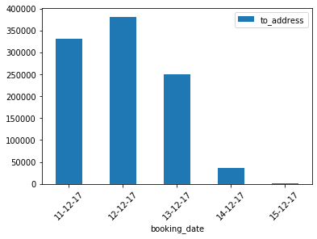

```python
df.groupby(by=['booking_date']).count().plot(kind="bar", rot=45)
```

From the bar chart above, we can see that in this period the highest shipping order was in 12 December 2017.

### 2. Data Preparation

The shipping address values are not in a standard format. Information of street name, kelurahan, kecamatan, city, etc. are stored in unstructured way. They are in one column. So we need to transform the value. People usually write an address in this common format:

*street name and number, kelurahan, kecamatan, city, province*

They are separated by commas. So let's try to extract information from some sample of address by splitting the data address by comma separator.

```python
sample_address = df["to_address"].sample(5).values
result = []
for i, item in enumerate(sample_address):
    result.append(item.split(","))
    print(result, len(result))
```

[output not shown]

From the sample above we can see that many of them do not follow the common format. Some of them are even misspelled. Hence, it is difficult to use the full address information for shipment destination segmentation. It is not an easy task to correct large number of address data one by one. For this analysis, let's just use the last item of the extracted address info, which is hopefully the city name.

```python
# function to get city name
# assumption: all city name are maximum in two words.
# example: + Jakarta Selatan
#          + Bekasi
#          + Banda Aceh
# city with word length more than 2 will be filled with nan value (invalid)
def get_city_name(address_list):
    result = []
    for each in address_list:
        city_name = each.split(",")[-1]
        words = city_name.split(" ")
        try:
            words.remove("")
        except:
            pass
        word_count = len(words)
        if word_count > 2:
            city_name = np.nan
        result.append(city_name)
    return result


df["city"] = get_city_name(df["to_address"].values)
df.head()
```

|  | to_address | booking_date | city |
| --- | --- | --- | --- |
| 0 | JL. RAYA PASIR PUTIH NO. 6 RT 05/RW 03 (DEPAN ... | 15-12-17 | NaN |
| 1 | LEGENDA WISATA ZONA EINSTEIN BLOK R 12 NO 6 WA... | 15-12-17 | NaN |
| 2 | PERM CLUSTER TIDAR ASRI BLOK C7 NO 17 KEL RANG... | 15-12-17 | DEPOK |
| 3 | CIBUNTU SAYURAN RT 12/06 KEL WARUNG MUNCANG BA... | 15-12-17 | BANDUN |
| 4 | JL.CILENGKRANG 1 KOMP TIRTAWENING NO 10 UJUNG ... | 15-12-17 | BANDUNG |

Remove data with invalid city name (NaN)

```python
df = df.dropna()
df.head()
```

|  | to_address | booking_date | city |
| --- | --- | --- | --- |
| 2 | PERM CLUSTER TIDAR ASRI BLOK C7 NO 17 KEL RANG... | 15-12-17 | DEPOK |
| 3 | CIBUNTU SAYURAN RT 12/06 KEL WARUNG MUNCANG BA... | 15-12-17 | BANDUN |
| 4 | JL.CILENGKRANG 1 KOMP TIRTAWENING NO 10 UJUNG ... | 15-12-17 | BANDUNG |
| 5 | JL MANDIOR BASYIR BEJI, DEPOK | 15-12-17 | DEPOK |
| 6 | KP.DUMPIT GANDASARI RT01 RW04 NMR RMH 66 KETOP... | 15-12-17 | TANGERAN |

Check how many data that we still have up to this step.

```python
data_size = df.shape
data_size
```

```
(812671, 3)
```

It is easier for us to segmentate geographical area by using longitude and latitude data. Lets get the longitude and latitude data of the city. We are using *Free* Nominatim API provided in geopy module for geocoding here.

```python
#uncomment this line below
#conda install -c conda-forge geopy
```

```python
from geopy.geocoders import Nominatim
from geopy.exc import GeocoderTimedOut
import time

geolocator = Nominatim(user_agent="test")

#function to get longitude and latitude of an address
def get_long_lat(city_list):
    result = []
    max_trial = 1
    for i, each in enumerate(city_list):
        trial = 0
        while(trial <max_trial):
            try:
                location = geolocator.geocode(each, timeout=5)
                result.append([location.longitude, location.latitude])
                break
            except:
                trial += 1
        if trial >= max_trial:
            result.append([np.nan, np.nan])
        time.sleep(1)
    longitude, latitude = zip(*result)
    return longitude, latitude
```

```python
sample_set = df.sample(5000)
sample_set.head()
```

|  | to_address | booking_date | city |
| --- | --- | --- | --- |
| 308893 | WARKOP KOPIZONE JL BOULEVARD RUKO TOPAZ F36 S... | 12-12-17 | MAKASSAR |
| 634559 | DAAN MOGOT PERGUDANGAN ARCADIA BLOK G II NO 2 ... | 12-12-17 | TANGERAN |
| 129714 | JL TANJAKNAGSI NO.13 KP.PAGER AGEUNG KULON RT... | 13-12-17 | TASIKM |
| 576630 | GRAHA ASRI ESTATE D-10 TALASALAPANG RAPPOCINI,... | 12-12-17 | MAKASSAR |
| 449270 | JLN RH DIDI SUKARDI KP BARU GU DANG GULA MERAH... | 12-12-17 | SUKABUMI |

```python
t0 = time.time()
result = get_long_lat(sample_set["city"])
t1 = time.time()
print("processing time: ", t1-t0/3600, " hours")

# Add longitude and latitude value to dataframe
sample_set["longitude"]= result[0]
sample_set["latitude"]= result[1]
sample_set.head()

# Drop NaN DATA
sample_set = sample_set.dropna()
print(sample_set.shape)

# Save sample data
sample_set.to_csv("5000_samples.csv")

# sample_set = pd.read_csv("5000_samples.csv")
# sample_set.head()
```

[output not shown]

Visualize the data

```python
#conda install -c conda-forge basemap
```

```python
sample_set.shape
```

```
(4275, 6)
```

```
sample_size: (347, 6)
```

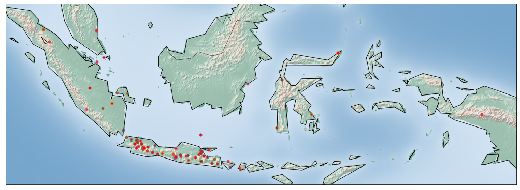

```python
# plt.scatter(sample_set["longitude"], sample_set["latitude"])
sample_set = pd.read_csv("sample_set.csv")
from mpl_toolkits.basemap import Basemap

# longitude and latitude limit of Indonesia
llon=95.31644
ulon=140.71813
llat=-10.1718
ulat=5.88969

pdf = sample_set[(sample_set['longitude'] > llon) & (sample_set['longitude'] < ulon) & (sample_set['latitude'] > llat) &(sample_set['latitude'] < ulat)]
print("sample_size:", pdf.shape)

fig=plt.figure(figsize=(18, 12) )

my_map = Basemap(projection='merc',
            resolution = 'c', area_thresh = 1000.0,
            llcrnrlon=llon, llcrnrlat=llat, #min longitude (llcrnrlon) and latitude (llcrnrlat)
            urcrnrlon=ulon, urcrnrlat=ulat) #max longitude (urcrnrlon) and latitude (urcrnrlat)

my_map.drawcoastlines()
my_map.drawcountries()
# my_map.drawmapboundary()
my_map.fillcontinents(color = 'white', alpha = 0.3)
my_map.shadedrelief()

# To collect data based on stations

xs,ys = my_map(np.asarray(pdf.longitude), np.asarray(pdf.latitude))
pdf['xm']= xs.tolist()
pdf['ym'] =ys.tolist()

#Visualization1
for index,row in pdf.iterrows():
#   x,y = my_map(row.Long, row.Lat)
   my_map.plot(row.xm, row.ym,markerfacecolor =([1,0,0]),  marker='o', markersize= 5, alpha = 0.75)
#plt.text(x,y,stn)
plt.show()
```

### 3. Modelling

```python
from sklearn.cluster import DBSCAN
import sklearn.utils
from sklearn.preprocessing import StandardScaler
sklearn.utils.check_random_state(1000)

Clus_dataSet = pdf[['xm','ym']]
Clus_dataSet = np.nan_to_num(Clus_dataSet)
Clus_dataSet = StandardScaler().fit_transform(Clus_dataSet)

# Compute DBSCAN
db = DBSCAN(eps=0.15, min_samples=10).fit(Clus_dataSet)
core_samples_mask = np.zeros_like(db.labels_, dtype=bool)
core_samples_mask[db.core_sample_indices_] = True
labels = db.labels_
pdf["Clus_Db"]=labels

realClusterNum=len(set(labels)) - (1 if -1 in labels else 0)
clusterNum = len(set(labels))


# A sample of clusters
print(pdf.shape)
pdf[["to_address", "city" ,"longitude", "latitude", "Clus_Db"]].head(5)
```

```
(347, 9)
```

|  | to_address | city | longitude | latitude | Clus_Db |
| --- | --- | --- | --- | --- | --- |
| 0 | JL.RAYA SUKATANI KEL.SUKADARMA SUKATANI,CIKARANG | CIKARANG | 107.036351 | -6.441701 | 0 |
| 1 | TAMAN CIBINONG ASRI BLOK E1 NO 30 RT 2 RW 19 ... | KAB.BOGOR | 106.784322 | -6.596498 | 0 |
| 2 | JL RAYA LEUWINUTUG GANG GAER RT, 02 / 02 NO... | CIBINONG | 107.411290 | -6.579034 | 0 |
| 3 | DUSUN KARANGANYAR RT04RW07 JAMBUSARI , JERUKLE... | CILACAP | 108.804762 | -7.462026 | -1 |
| 4 | C/O LOGAM PELITA, JL.CIREBON NO.78, KOTA MEDA... | MEDAN | 98.673826 | 3.589665 | 1 |

```python
set(labels)
```

```
{-1, 0, 1, 2, 3, 4}
```

```
Cluster 0, Centroid longitude: 107.19099622566775,  Centroid latitude: -6.591994538194449,  Centroid_location: None,  Cluster_Size: 144
Cluster 1, Centroid longitude: 98.67382610000003,  Centroid latitude: 3.589665400000001,  Centroid_location: None,  Cluster_Size: 15
Cluster 2, Centroid longitude: 110.56208327425102,  Centroid latitude: -7.7361134119047685,  Centroid_location: None,  Cluster_Size: 63
Cluster 3, Centroid longitude: 112.71711548227296,  Centroid latitude: -7.42431891057692,  Centroid_location: None,  Cluster_Size: 52
Cluster 4, Centroid longitude: 112.68798721390598,  Centroid latitude: -8.104798149999999,  Centroid_location: None,  Cluster_Size: 10
```

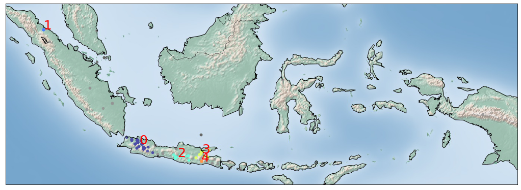

```python
from mpl_toolkits.basemap import Basemap
import matplotlib.pyplot as plt
from pylab import rcParams
%matplotlib inline
rcParams['figure.figsize'] = (18,12)

my_map = Basemap(projection='merc',
            resolution = 'l', area_thresh = 1000.0,
            llcrnrlon=llon, llcrnrlat=llat, #min longitude (llcrnrlon) and latitude (llcrnrlat)
            urcrnrlon=ulon, urcrnrlat=ulat) #max longitude (urcrnrlon) and latitude (urcrnrlat)

my_map.drawcoastlines()
my_map.drawcountries()
#my_map.drawmapboundary()
my_map.fillcontinents(color = 'white', alpha = 0.3)
my_map.shadedrelief()

# To create a color map
colors = plt.get_cmap('jet')(np.linspace(0.0, 1.0, clusterNum))

#Visualization1
for clust_number in set(labels):
    c=(([0.4,0.4,0.4]) if clust_number == -1 else colors[np.int(clust_number)])
    clust_set = pdf[pdf.Clus_Db == clust_number]
    my_map.scatter(clust_set.xm, clust_set.ym, color =c,  marker='o', s= 20, alpha = 0.85)
    if clust_number != -1:
        cenx=np.mean(clust_set.xm)
        ceny=np.mean(clust_set.ym)

        cenLong = np.mean(clust_set.longitude)
        cenLat = np.mean(clust_set.latitude)
        cenLocation = geolocator.reverse(cenLat, cenLong).address
        clusterSize = len(pdf[pdf["Clus_Db"] == clust_number].values)
        plt.text(cenx,ceny,str(clust_number), fontsize=25, color='red',)
        print ("Cluster "+str(clust_number)+', Centroid longitude: '+ str(cenLong)+',  Centroid latitude: '+ str(cenLat)+',  Centroid_location: '+ str(cenLocation)+',  Cluster_Size: '+ str(clusterSize))
```

### 4. Analysis

#### What is the best decision we can make from this data?

We can expand our shipment scope by providing new courier post in these five clusters.

#### Suggestions for future

It will be easier and useful for data science team to use a standardized data format. For example the shipment address in our data. The analysis output quality is affected by the quality of the data. Data with unstandardized format contribute noises in our dataset.

If we have enough resource, It will be better if we use Google Map Geocoding API for our geocoding process. I think it will be helpful because Google has a more complete geolocation data.